# Practice ggplot2

2020-05-20

# 1 R Markdown

# 2 Data

This code reads in the data we will need from the csv files:

```r
gapminder2011 <- read_csv("data/Gapminder_vars_2011.csv")
gapminder2011_long <- read_csv("data/Gapminder_vars_2011_long.csv")
pasilla_data <- read_csv("data/gene_expr_pasilla_results.csv")
```

# 3 Bar plot

This is the code from the slides. Change the code to do the following:

- use the variable `members_oecd_g77` for the bars and make the barplot horizontal instead of vertical
- change the fill to `WaterSourcePrct_2011_quart`
- use `position="dodge"` as an argument to `geom_bar()`
- change y axis label to “OECD g77 Members”
- change the order of the y axis with `scale_y_discrete(limits = c(NA,"others","oecd","g77"))`
- change the color of the bars to a different palette

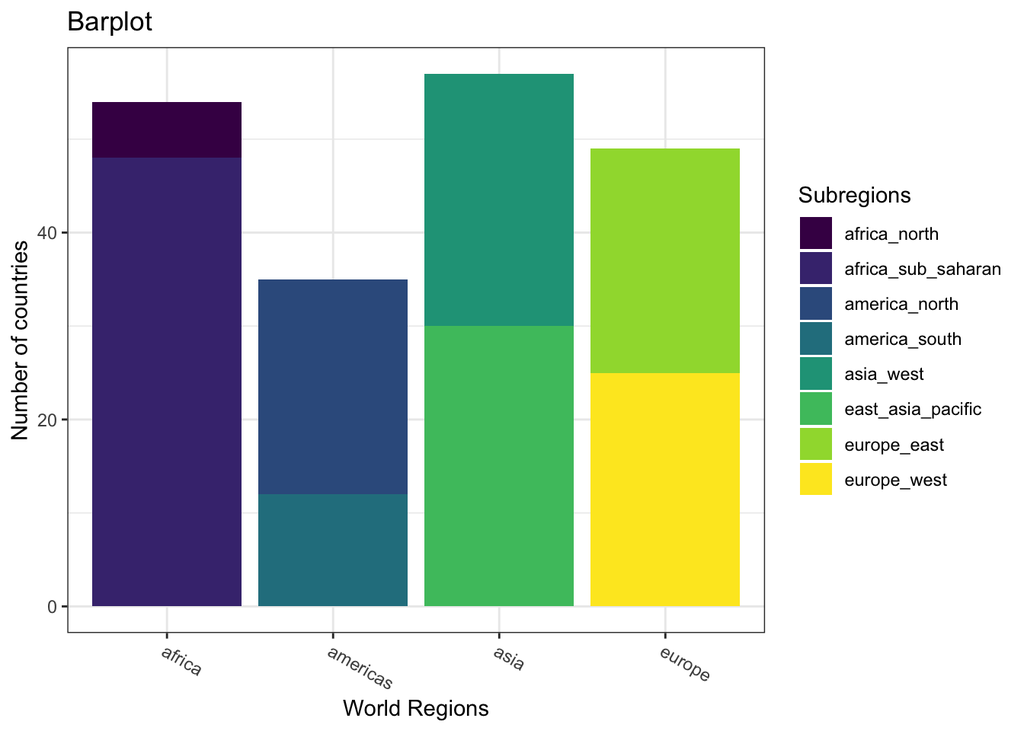

```r
ggplot(data = gapminder2011,
       aes(x = four_regions,
           fill = eight_regions)) +
  geom_bar() +
  labs(x = "World Regions",
       y = "Number of countries",
       title = "Barplot") +
  theme_bw() +
  theme(
    axis.text.x = element_text(angle = -30, hjust = 0)) +
  scale_fill_viridis_d(name = "Subregions")
```

# 4 Bubble plot

This is the code from the bubble plot.

- Change x to be mapped to `IncomePP`
- Change the x label to be accurate
- Map shape to `members_oecd_g77`
- Change the scale of the x-axis to be on the log10 scale using `scale_x_log10`

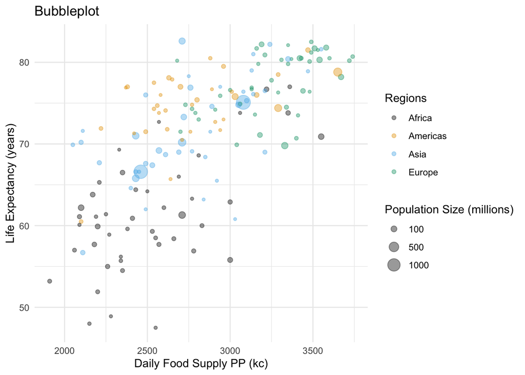

```r
ggplot(data = gapminder2011,
       aes(x = FoodSupplykcPPD,
           y = LifeExpectancyYrs,
           color = four_regions,
           size = population)) +
  geom_point(alpha = 0.4) +
  scale_color_colorblind(
    name = "Regions",
    labels = c("Africa", "Americas",
               "Asia", "Europe")
  ) +
  scale_size(
    name = "Population Size (millions)",
    breaks = c(1e08,5e08,1e09),
    labels = c(100,500,1000)
  ) +
  theme_minimal() +
  labs(
    x = "Daily Food Supply PP (kc)",
    y = "Life Expectancy (years)",
    title = "Bubbleplot"
    )
```

# 5 Histogram

This is the code from the slides. Change the following code to do the following:

- change the width of the histogram bins to 1.5 (hint: type `?geom_histogram` in the console to find the argument)
- add a layer of `geom_density()` with alpha = 0.4
- Why doesn’t the density line show up? Add `aes(y=..density..)` to the histogram function arguments.
- facet by `four_regions`
- change the theme to `theme_bw()`
- fill by `eight_regions`, color by `four_regions`
- change the fill scale to viridis (discrete version is `scale_fill_viridis_d`)
- remove the color legend
- change the title to “Histogram and Density of Life Expectancy”

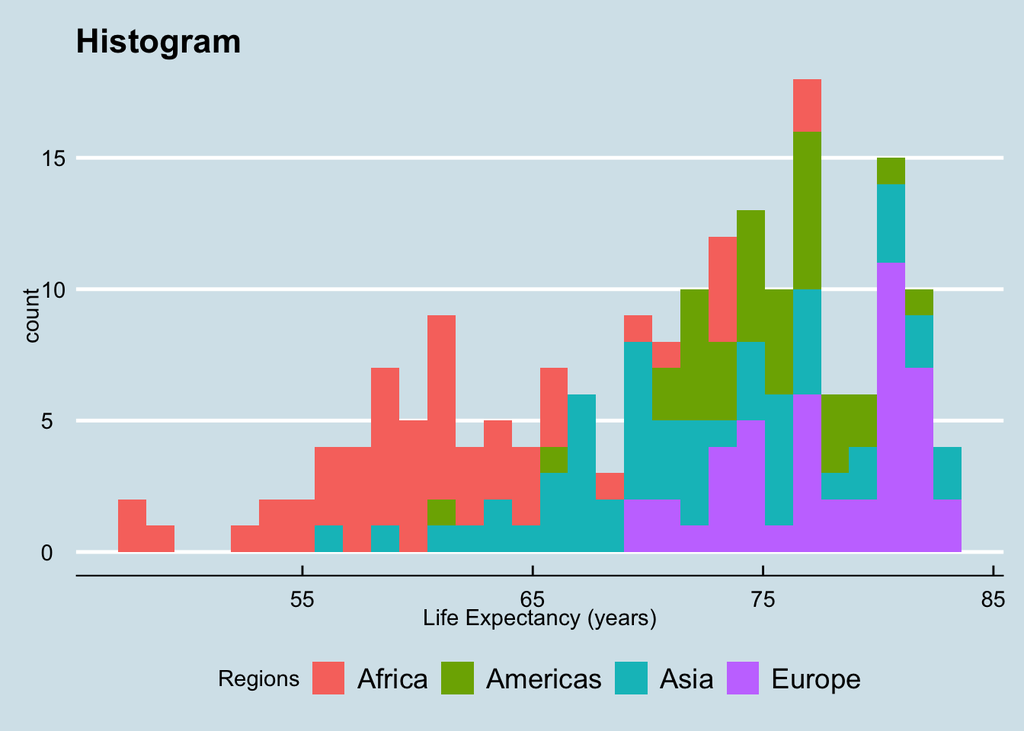

```r
ggplot(data = gapminder2011,
       aes(x = LifeExpectancyYrs,
           fill = four_regions)) +
  geom_histogram() +
  scale_fill_discrete(
    name = "Regions",
    labels = c("Africa", "Americas",
               "Asia", "Europe")
  ) +
  labs(
    x = "Life Expectancy (years)",
    title = "Histogram"
    ) +
  ggthemes::theme_economist() +
  theme(
    legend.position="bottom"
  )
```